# Project R

Sean Park

10.30.2022

In this project you will be working with R base and Tidyverse. - *Knit* the empty file (to make sure everything is working) - Consistently *knit* the file each time you answer a question

Students enrolled in CAP4755 should only solve: **1, 2, 3, 4, 6, 7, 8, and 9.**

## R Basics (40%)

1. Compute the difference between 2022 and the year you started programming divide this by the difference between 2022 and the year you were born. Multiply this with 100 to get the percentage of your life you have been programming

```r
#Code here
sum(2022-2022) / sum(2022-1990) * 100
```

```
## [1] 0
```

```r
#started programming at the start of this class - 0% is accurate.
```

2. Compute the mean of the square root of a vector of 100 random numbers. What happens?

```r
#Code here
mean(sqrt(rnorm(100)))
```

```
## [1] NaN
```

```r
#Failure to get a number - error message NaNs produced.
```

3. Make a vector from 1 to 100. Make a for-loop which runs through the whole vector. Multiply the elements which are smaller than 11 and larger than 90 with 10 and the other elements with 0.1

```r
#Code here
x = seq(1:100)
for (y in 1:length(x)){
  if (x[y] < 11 | x[y] > 90)
    print(x[y]*10) else print(x[y]*0.1)
}
```

```
## [1] 10
## [1] 20
## [1] 30
## [1] 40
## [1] 50
## [1] 60
## [1] 70
## [1] 80
## [1] 90
## [1] 100
## [1] 1.1
## [1] 1.2
## [1] 1.3
## [1] 1.4
## [1] 1.5
```

[output cut: 85 more lines]

```r
#this one was so tricky
```

4. Write a function for the previous ToDo, so that you can feed it any vector you like (as argument). Use a for-loop in the function to do the computation with each element. Use the standard R function length in the specification of the counter.

```r
#Code here
myfunction = function(x) {
  for (y in 1:length(x)){
    if (x[y] < 11 | x[y] > 90)
      print(x[y]*10) else print(x[y]*0.1)
  }
  return(x)
}
```

## Baby names distribution (55%)

We will look into the distribution of baby names. This data set has almost 2 millions names from 1880 to 2017. It was provided by the Social Security Administration. It has the following variables:

- year: birth year
- sex: Female or Male
- name: baby name
- n: number of babies named “name” in that year with that sex

##### Data Wrangling

Read the data in R and called it **bbnames**:

```r
#Code here
# Load the data
bbnames = read.csv("https://pages.uwf.edu/acohen/teaching/datasets/bbnames.csv")
```

5. Find the proportions of people born in the same year and with same sex. That is prop = n divided by total number of applicants in that year and that sex. Create a new variable `prop` using `mutate` and added to **bbnames**:

```r
#Code here
library(tidyverse)
bbnames1 = bbnames %>%
  group_by(year, sex) %>%
  mutate(prop = n/sum(n))
```

6. Find the most popular, all time, name for each gender (hints: answer for females starts with **M** and males with **J**):

```r
#Code here
bbnames %>%
  filter(sex == "F") %>%
  head(1)
```

```
##   year sex name    n
## 1 1880   F Mary 7065
```

```r
bbnames %>%
  filter(sex == "M") %>%
  head(1)
```

```
##   year sex name    n
## 1 1880   M John 9655
```

```r
#Mary at 7065, and John at 9655
```

7. Create a new data frame while creating a new variable `age` and filter by `age` - Pick a threshold that would keep only people who may still alive (you may use the age expectancy):

```r
#Code here
newdata = bbnames %>%
  mutate(age = 2022 - year) %>%
  filter(age <= 77)
#77 was life expectancy from CDC website
```

##### Visualization

8. Use ggplot to plot the distribution of the name *John*. Use geom_bar, geom_line, and facet_wrap to separate females and males.

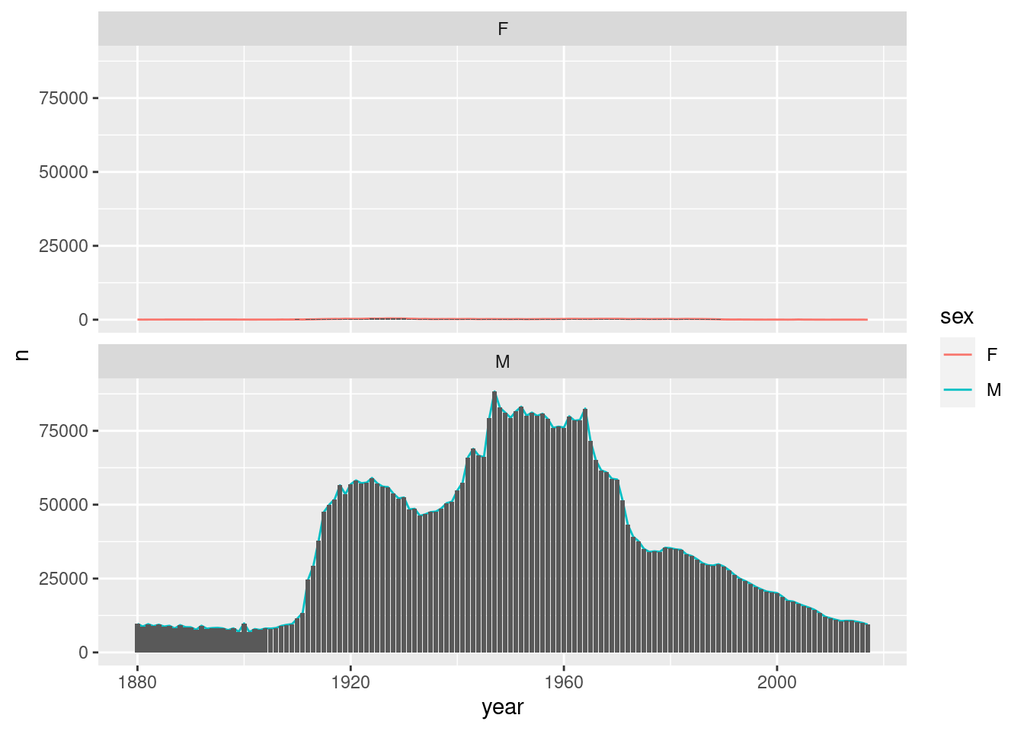

```r
#Code here
john = bbnames %>%
  filter(name == "John")
ggplot(data = john, aes(x = year, y = n)) +
  geom_line(aes(color = sex)) +
  geom_bar(stat = "identity") +
  facet_wrap(~sex, nrow = 2)
```

9. Use ggplot to plot the distribution of the name of your choice. Use geom_bar, geom_line, and facet_wrap to separate females and males.

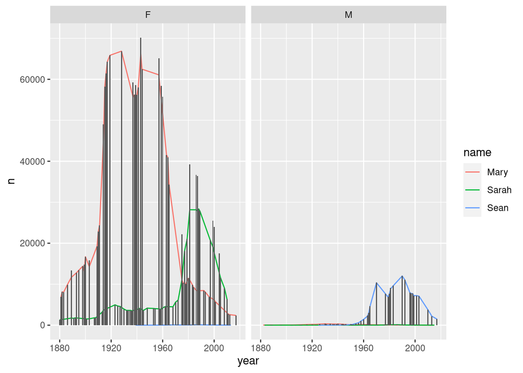

```r
#Code here
my_names = bbnames %>%
  filter(name == c("Sarah", "Sean", "Mary"))
ggplot(data = my_names, aes(x = year, y = n)) +
  geom_line(aes(color = name)) +
  geom_bar(stat = "identity") +
  facet_wrap(~sex, nrow = 1)
```

## Diploma problem (hat-check) (5%)

10. You most likely heard about this problem before. Smith College is a residential women’s liberal arts college in Northampton, MA that is steeped in tradition. One such tradition is to give each student at graduation a diploma at random. At the end of the ceremony, a diploma circle is formed, and students pass the diplomas that they receive to the person next to them, and step out once they’ve received their diploma. What is the expected number of students who receive their diplomas in the initial disbursement?

The analytic solution (of the expect value) is easy to derive. Let $X_i$ is the event that $ith$ student receives their diploma then $E(X_i)=1/n$, for all i (the diplomas are uniformly distributed). n is the number of diplomas (students). Thus, if $Y$ is the sum of all the events $X_i$, then $E(Y)=1$. It is sometimes kind of surprising that the expected number of students receiving their diplomas in the initial disbursement does not depend on $n$. The variance can be more difficult to derive since $X_i$ are dependent.

We will solve the problem using simulations with R. Simulate the problem and find the expected value and the variance of the number of students who receive their diplomas in the initial giving.

```r
#Code here
#I know the sample size n is arbitrary and shouldnt have much impact on value and variance, and I know this will be using the if/else function but I cannot create any scripts worthwhile on this one.
```